# Cyclistic Bike Trips

Bisola Ogunye

2023-10-05

## Objective

The objective of this analysis is to uncover actionable insights to drive the conversion of casual riders into Cyclistic annual members by understanding the differences between annual Members and casual riders.

### Questions to guide analysis

- What is the significant difference between casual riders and annual members?
- Which dock stations do most casual riders/annual members start trips from?
- Which dock stations do most casual riders/annual members end trips at?
- Which bike type do casual riders/annual members mostly use?
- What is the average trip duration for casual riders/annual members?
- What day of the week do casual riders/annual members mainly start trips?

## Packages

For this project, the tidyverse packaged was installed and loaded.

```r
library(tidyverse)
library(formatR)
library(shiny)
```

## Preparing the data

All files to be used during the course of this project were obtained for the company’s database where the data is stored by month. which were in turn saved in the datasets directory:

**~/data_analytics_portfolio_project/GDAC/Case_Study_1/datasets**

Then the file names were saved in the variable ‘all_files’.

```r
all_files <- list.files(pattern = "*.csv")
all_files
```

```
##  [1] "202201-divvy-tripdata.csv" "202202-divvy-tripdata.csv"
##  [3] "202203-divvy-tripdata.csv" "202204-divvy-tripdata.csv"
##  [5] "202205-divvy-tripdata.csv" "202206-divvy-tripdata.csv"
##  [7] "202207-divvy-tripdata.csv" "202208-divvy-tripdata.csv"
##  [9] "202209-divvy-tripdata.csv" "202210-divvy-tripdata.csv"
## [11] "202211-divvy-tripdata.csv" "202212-divvy-tripdata.csv"
## [13] "202301-divvy-tripdata.csv" "202302-divvy-tripdata.csv"
## [15] "202303-divvy-tripdata.csv" "202304-divvy-tripdata.csv"
## [17] "202305-divvy-tripdata.csv" "202306-divvy-tripdata.csv"
## [19] "202307-divvy-tripdata.csv"
```

The the content of ‘all_files’ were read into a single data frame.

```r
all_df <- map_df(all_files, read_csv)
```

The following commands were run to get a feel of the entire data.

- View structure of the data

```
## spc_tbl_ [8,825,826 × 13] (S3: spec_tbl_df/tbl_df/tbl/data.frame)
##  $ ride_id           : chr [1:8825826] "C2F7DD78E82EC875" "A6CF8980A652D272" "BD0F91DFF741C66D" "CBB80ED419105406" ...
##  $ rideable_type     : chr [1:8825826] "electric_bike" "electric_bike" "classic_bike" "classic_bike" ...
##  $ started_at        : POSIXct[1:8825826], format: "2022-01-13 11:59:47" "2022-01-10 08:41:56" ...
##  $ ended_at          : POSIXct[1:8825826], format: "2022-01-13 12:02:44" "2022-01-10 08:46:17" ...
##  $ start_station_name: chr [1:8825826] "Glenwood Ave & Touhy Ave" "Glenwood Ave & Touhy Ave" "Sheffield Ave & Fullerton Ave" "Clark St & Bryn Mawr Ave" ...
##  $ start_station_id  : chr [1:8825826] "525" "525" "TA1306000016" "KA1504000151" ...
##  $ end_station_name  : chr [1:8825826] "Clark St & Touhy Ave" "Clark St & Touhy Ave" "Greenview Ave & Fullerton Ave" "Paulina St & Montrose Ave" ...
##  $ end_station_id    : chr [1:8825826] "RP-007" "RP-007" "TA1307000001" "TA1309000021" ...
##  $ start_lat         : num [1:8825826] 42 42 41.9 42 41.9 ...
##  $ start_lng         : num [1:8825826] -87.7 -87.7 -87.7 -87.7 -87.6 ...
##  $ end_lat           : num [1:8825826] 42 42 41.9 42 41.9 ...
##  $ end_lng           : num [1:8825826] -87.7 -87.7 -87.7 -87.7 -87.6 ...
##  $ member_casual     : chr [1:8825826] "casual" "casual" "member" "casual" ...
##  - attr(*, "spec")=
##   .. cols(
##   ..   ride_id = col_character(),
##   ..   rideable_type = col_character(),
##   ..   started_at = col_datetime(format = ""),
##   ..   ended_at = col_datetime(format = ""),
##   ..   start_station_name = col_character(),
##   ..   start_station_id = col_character(),
##   ..   end_station_name = col_character(),
##   ..   end_station_id = col_character(),
##   ..   start_lat = col_double(),
##   ..   start_lng = col_double(),
##   ..   end_lat = col_double(),
##   ..   end_lng = col_double(),
##   ..   member_casual = col_character()
##   .. )
##  - attr(*, "problems")=<externalptr>
```

- Preview column names

```
##  [1] "ride_id"            "rideable_type"      "started_at"
##  [4] "ended_at"           "start_station_name" "start_station_id"
##  [7] "end_station_name"   "end_station_id"     "start_lat"
## [10] "start_lng"          "end_lat"            "end_lng"
## [13] "member_casual"
```

- Preview the data

```
## Rows: 8,825,826
## Columns: 13
## $ ride_id            <chr> "C2F7DD78E82EC875", "A6CF8980A652D272", "BD0F91DFF7…
## $ rideable_type      <chr> "electric_bike", "electric_bike", "classic_bike", "…
## $ started_at         <dttm> 2022-01-13 11:59:47, 2022-01-10 08:41:56, 2022-01-…
## $ ended_at           <dttm> 2022-01-13 12:02:44, 2022-01-10 08:46:17, 2022-01-…
## $ start_station_name <chr> "Glenwood Ave & Touhy Ave", "Glenwood Ave & Touhy A…
## $ start_station_id   <chr> "525", "525", "TA1306000016", "KA1504000151", "TA13…
## $ end_station_name   <chr> "Clark St & Touhy Ave", "Clark St & Touhy Ave", "Gr…
## $ end_station_id     <chr> "RP-007", "RP-007", "TA1307000001", "TA1309000021",…
## $ start_lat          <dbl> 42.01280, 42.01276, 41.92560, 41.98359, 41.87785, 4…
## $ start_lng          <dbl> -87.66591, -87.66597, -87.65371, -87.66915, -87.624…
## $ end_lat            <dbl> 42.01256, 42.01256, 41.92533, 41.96151, 41.88462, 4…
## $ end_lng            <dbl> -87.67437, -87.67437, -87.66580, -87.67139, -87.627…
## $ member_casual      <chr> "casual", "casual", "member", "casual", "member", "…
```

- First 6 rows

```
## # A tibble: 6 × 13
##   ride_id          rideable_type started_at          ended_at
##   <chr>            <chr>         <dttm>              <dttm>
## 1 C2F7DD78E82EC875 electric_bike 2022-01-13 11:59:47 2022-01-13 12:02:44
## 2 A6CF8980A652D272 electric_bike 2022-01-10 08:41:56 2022-01-10 08:46:17
## 3 BD0F91DFF741C66D classic_bike  2022-01-25 04:53:40 2022-01-25 04:58:01
## 4 CBB80ED419105406 classic_bike  2022-01-04 00:18:04 2022-01-04 00:33:00
## 5 DDC963BFDDA51EEA classic_bike  2022-01-20 01:31:10 2022-01-20 01:37:12
## 6 A39C6F6CC0586C0B classic_bike  2022-01-11 18:48:09 2022-01-11 18:51:31
## # ℹ 9 more variables: start_station_name <chr>, start_station_id <chr>,
## #   end_station_name <chr>, end_station_id <chr>, start_lat <dbl>,
## #   start_lng <dbl>, end_lat <dbl>, end_lng <dbl>, member_casual <chr>
```

- Last 6 rows

```
## # A tibble: 6 × 13
##   ride_id          rideable_type started_at          ended_at
##   <chr>            <chr>         <dttm>              <dttm>
## 1 F874F0AB1BAE5A2A electric_bike 2023-07-15 15:01:11 2023-07-15 15:09:41
## 2 57F5743A5828DA62 electric_bike 2023-07-14 19:17:13 2023-07-14 19:26:31
## 3 2FF218D4C8F0EF1C electric_bike 2023-07-14 19:16:13 2023-07-14 19:16:16
## 4 2661FBD1F5A1C76D electric_bike 2023-07-15 13:34:00 2023-07-15 13:43:13
## 5 9CF4B70C23E033B1 electric_bike 2023-07-06 20:52:09 2023-07-06 21:01:13
## 6 7AD613C71AD143CD electric_bike 2023-07-07 18:47:27 2023-07-07 18:51:46
## # ℹ 9 more variables: start_station_name <chr>, start_station_id <chr>,
## #   end_station_name <chr>, end_station_id <chr>, start_lat <dbl>,
## #   start_lng <dbl>, end_lat <dbl>, end_lng <dbl>, member_casual <chr>
```

## Processing the data

The following steps were followed for this phase.

- Columns necessary for the project were selected
- Rename columns for easy readability
- Remove NAs
- Add columns for
  - ‘trip_duration’ (length of bike ride)
  - ‘day_of_week’ (weekday the ride started)

```r
clean_df <- all_df %>%
    select("ride_id", "rideable_type", "started_at", "ended_at", "start_station_name",
        "start_station_id", "end_station_name", "end_station_id", "member_casual") %>%
    rename(trip_id = ride_id, bike_type = rideable_type, start_time = started_at,
        end_time = ended_at, from_station_name = start_station_name, to_station_name = end_station_name,
        from_station_id = start_station_id, to_station_id = end_station_id, usertype = member_casual) %>%
    na.omit() %>%
    mutate(trip_duration = as.numeric(difftime(end_time, start_time, units = "mins")),
        day_of_week = wday(start_time, label = TRUE, abbr = FALSE))
```

```
## Rows: 6,763,866
## Columns: 11
## $ trip_id           <chr> "C2F7DD78E82EC875", "A6CF8980A652D272", "BD0F91DFF74…
## $ bike_type         <chr> "electric_bike", "electric_bike", "classic_bike", "c…
## $ start_time        <dttm> 2022-01-13 11:59:47, 2022-01-10 08:41:56, 2022-01-2…
## $ end_time          <dttm> 2022-01-13 12:02:44, 2022-01-10 08:46:17, 2022-01-2…
## $ from_station_name <chr> "Glenwood Ave & Touhy Ave", "Glenwood Ave & Touhy Av…
## $ from_station_id   <chr> "525", "525", "TA1306000016", "KA1504000151", "TA130…
## $ to_station_name   <chr> "Clark St & Touhy Ave", "Clark St & Touhy Ave", "Gre…
## $ to_station_id     <chr> "RP-007", "RP-007", "TA1307000001", "TA1309000021", …
## $ usertype          <chr> "casual", "casual", "member", "casual", "member", "m…
## $ trip_duration     <dbl> 2.9500000, 4.3500000, 4.3500000, 14.9333333, 6.03333…
## $ day_of_week       <ord> Thursday, Monday, Tuesday, Tuesday, Thursday, Tuesda…
```

After a review of the minimum and maximum ‘trip_duration’, we can see that some rides have negative duration and some rides were for more than a day (the highest ‘trip_duration’ being almost 23 days).

```r
min(clean_df$trip_duration)  # -168.7
```

```
## [1] -168.7
```

```r
max(clean_df$trip_duration)  # 34354.07 approx. 23 days
```

```
## [1] 34354.07
```

However, for this analysis, these groups qualify as bad data and are removed.

```r
clean_df <- filter(clean_df, trip_duration >= 1, trip_duration <= (24 * 60))
```

```
## Rows: 6,632,878
## Columns: 11
## $ trip_id           <chr> "C2F7DD78E82EC875", "A6CF8980A652D272", "BD0F91DFF74…
## $ bike_type         <chr> "electric_bike", "electric_bike", "classic_bike", "c…
## $ start_time        <dttm> 2022-01-13 11:59:47, 2022-01-10 08:41:56, 2022-01-2…
## $ end_time          <dttm> 2022-01-13 12:02:44, 2022-01-10 08:46:17, 2022-01-2…
## $ from_station_name <chr> "Glenwood Ave & Touhy Ave", "Glenwood Ave & Touhy Av…
## $ from_station_id   <chr> "525", "525", "TA1306000016", "KA1504000151", "TA130…
## $ to_station_name   <chr> "Clark St & Touhy Ave", "Clark St & Touhy Ave", "Gre…
## $ to_station_id     <chr> "RP-007", "RP-007", "TA1307000001", "TA1309000021", …
## $ usertype          <chr> "casual", "casual", "member", "casual", "member", "m…
## $ trip_duration     <dbl> 2.950000, 4.350000, 4.350000, 14.933333, 6.033333, 3…
## $ day_of_week       <ord> Thursday, Monday, Tuesday, Tuesday, Thursday, Tuesda…
```

Then, we verify that all NAs have been removed and that the data has no duplicates.

```r
anyNA(clean_df)  #FALSE
```

```
## [1] FALSE
```

```r
colSums(is.na(clean_df))
```

```
##           trip_id         bike_type        start_time          end_time
##                 0                 0                 0                 0
## from_station_name   from_station_id   to_station_name     to_station_id
##                 0                 0                 0                 0
##          usertype     trip_duration       day_of_week
##                 0                 0                 0
```

```r
sum(duplicated(clean_df$trip_id))  # 0
```

```
## [1] 0
```

## Analyze

In this phase, we will be performing Descriptive analysis to help us understand what is going on in the data.

We create summary tables to give the whole picture of the data.

#### Get general summary of the trip duration

```
##     Min.  1st Qu.   Median     Mean  3rd Qu.     Max.
##    1.000    6.117   10.550   16.980   18.833 1439.367
```

#### The average ride time by each day for members vs casual users

```
##    clean_df$usertype clean_df$day_of_week clean_df$trip_duration
## 1             casual               Sunday               27.34101
## 2             member               Sunday               14.04467
## 3             casual               Monday               24.33986
## 4             member               Monday               12.09388
## 5             casual              Tuesday               21.54487
## 6             member              Tuesday               11.95031
## 7             casual            Wednesday               20.49670
## 8             member            Wednesday               11.92642
## 9             casual             Thursday               21.18774
## 10            member             Thursday               12.09040
## 11            casual               Friday               22.64906
## 12            member               Friday               12.33394
## 13            casual             Saturday               26.75663
## 14            member             Saturday               14.17933
```

#### Generate data frames

##### Summarize table grouping on the user type**

```
## # A tibble: 2 × 8
##   usertype row_count percentage avg_trip_duration max_trip_duration
##   <chr>        <int>      <dbl>             <dbl>             <dbl>
## 1 casual     2576677       38.8              23.9             1439.
## 2 member     4056201       61.2              12.6             1436.
## # ℹ 3 more variables: min_trip_duration <dbl>, mode_bike_type <chr>,
## #   mode_day_of_week <ord>
```

**POINTS TO NOTE**

- There are more member users than casual.

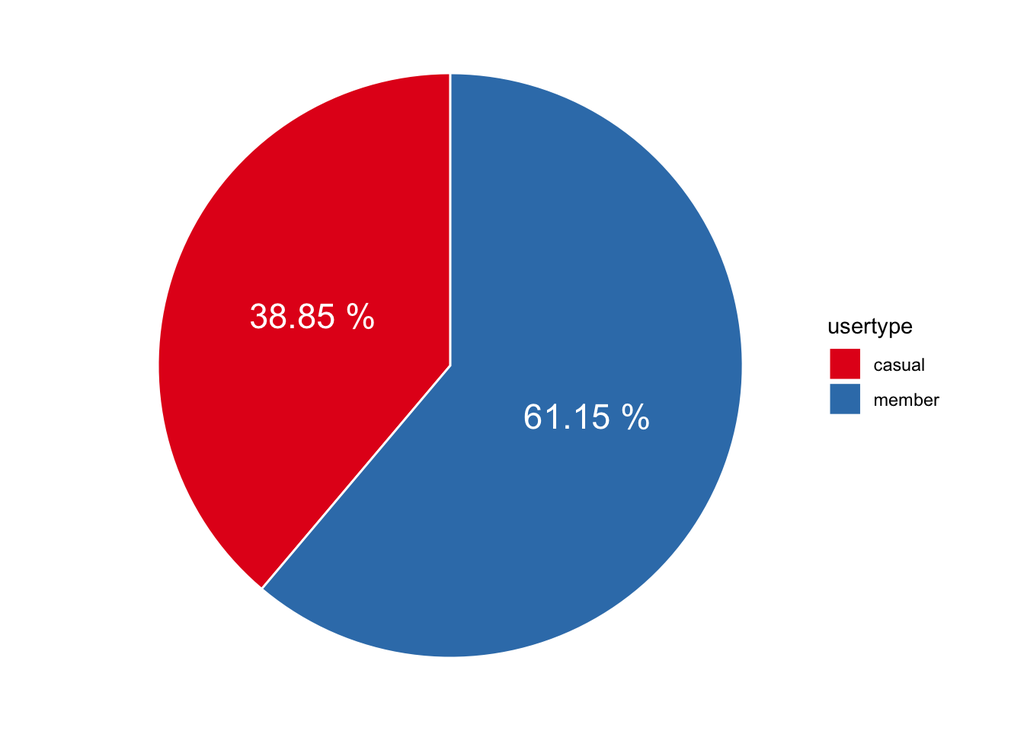

- The average trip duration for casual users is more than members.
- Both user type use classic bikes.

##### How long do both user types commute for each day of the week?

```
## # A tibble: 14 × 8
##    usertype day_of_week row_count percentage avg_trip_duration max_trip_duration
##    <chr>    <ord>           <int>      <dbl>             <dbl>             <dbl>
##  1 casual   Sunday         435354       6.56              27.3             1439.
##  2 casual   Monday         311433       4.7               24.3             1436.
##  3 casual   Tuesday        293176       4.42              21.5             1438.
##  4 casual   Wednesday      297132       4.48              20.5             1438.
##  5 casual   Thursday       336534       5.07              21.2             1437.
##  6 casual   Friday         369258       5.57              22.6             1439.
##  7 casual   Saturday       533790       8.05              26.8             1438.
##  8 member   Sunday         456901       6.89              14.0             1424.
##  9 member   Monday         583343       8.79              12.1             1432.
## 10 member   Tuesday        640420       9.66              12.0             1436.
## 11 member   Wednesday      640950       9.66              11.9             1419.
## 12 member   Thursday       648775       9.78              12.1             1435.
## 13 member   Friday         566837       8.55              12.3             1435.
## 14 member   Saturday       518975       7.82              14.2             1417.
## # ℹ 2 more variables: min_trip_duration <dbl>, mode_bike_type <chr>
```

**POINTS TO NOTE**

- Members tend to bike more during weekdays while casual users tend to bike more during weekends.
- Casual riders mostly ride on Saturdays while members mostly ride on Thursdays.

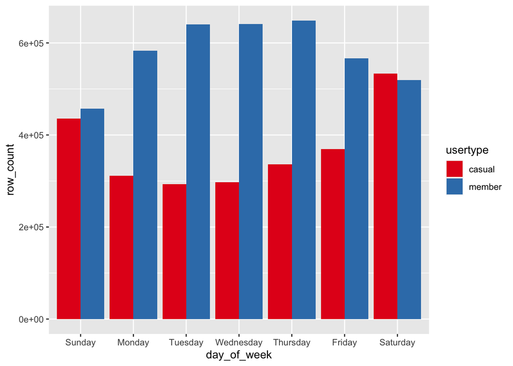

- Both user types tend to ride longer on weekends.

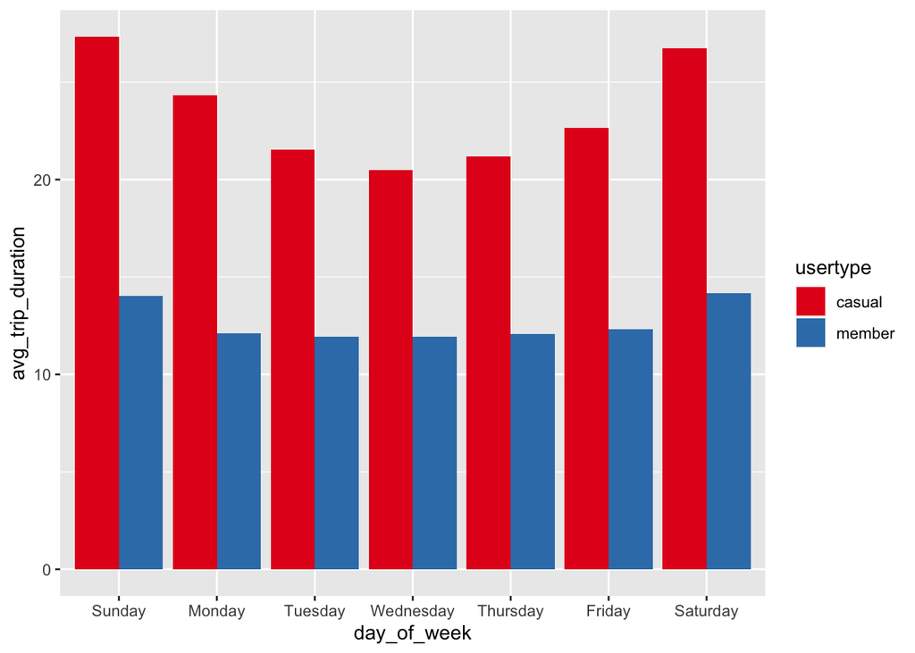

##### Which bike types do users mostly and which day of the week is common to the bike types?

We would be getting more information on what bike type both user types make use of.

```
## # A tibble: 35 × 9
## # Groups:   usertype, bike_type [5]
##    usertype bike_type    day_of_week row_count percentage avg_trip_duration
##    <chr>    <chr>        <ord>           <int>      <dbl>             <dbl>
##  1 casual   classic_bike Sunday         231922       3.5               28.1
##  2 casual   classic_bike Monday         155602       2.35              25.5
##  3 casual   classic_bike Tuesday        145007       2.19              23.2
##  4 casual   classic_bike Wednesday      143656       2.17              22.1
##  5 casual   classic_bike Thursday       166439       2.51              22.6
##  6 casual   classic_bike Friday         184394       2.78              24.0
##  7 casual   classic_bike Saturday       290375       4.38              27.4
##  8 casual   docked_bike  Sunday          46463       0.7               51.6
##  9 casual   docked_bike  Monday          29480       0.44              51.9
## 10 casual   docked_bike  Tuesday         23814       0.36              48.0
## # ℹ 25 more rows
## # ℹ 3 more variables: max_trip_duration <dbl>, min_trip_duration <dbl>,
## #   mode_day_of_week <ord>
```

**POINTS TO NOTE**

- Only casual users make use of docked bikes.
- Both user types tend to spend lesser time using electric bikes.

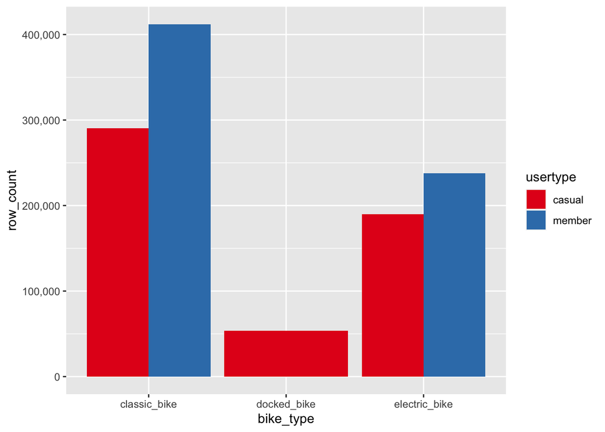

- Members mostly use classic bikes during weekdays while casual users mostly use classic bikes during weekends.

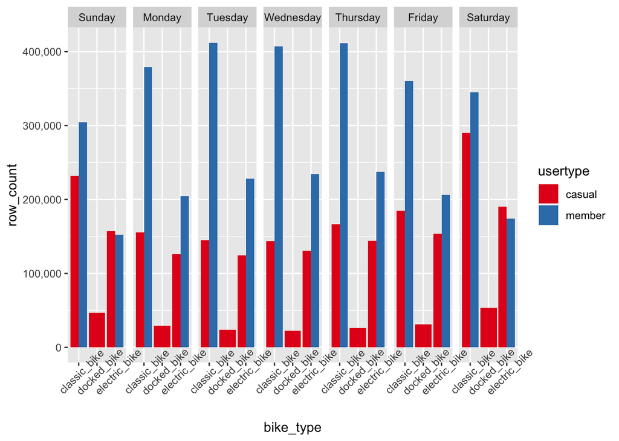

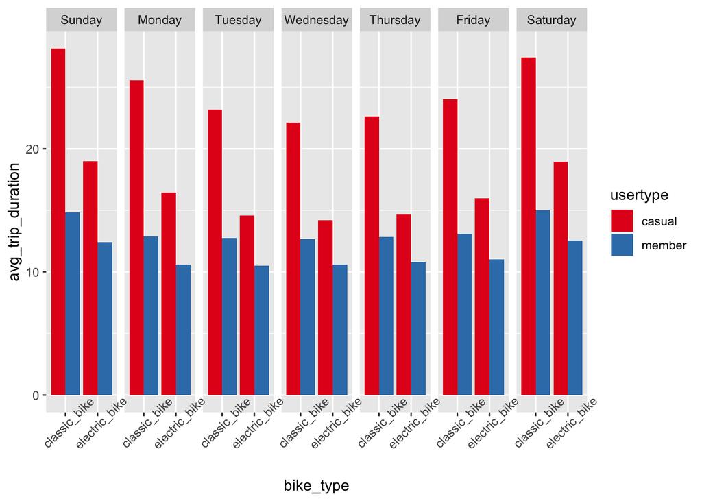

We go further to analyze by average trips per quarter and month.

```
## # A tibble: 38 × 9
## # Groups:   year, mnth, qtr [19]
##     year mnth  qtr   usertype row_count percentage avg_trip_duration
##    <dbl> <chr> <chr> <chr>        <int>      <dbl>             <dbl>
##  1  2022 Feb   Q1    casual       14960       0.23              21.6
##  2  2022 Feb   Q1    member       72682       1.1               10.8
##  3  2022 Jan   Q1    casual       12464       0.19              18.3
##  4  2022 Jan   Q1    member       66575       1                 10.4
##  5  2022 Mar   Q1    casual       66378       1                 26.7
##  6  2022 Mar   Q1    member      146494       2.21              11.9
##  7  2022 Apr   Q2    casual       90806       1.37              26.0
##  8  2022 Apr   Q2    member      177719       2.68              11.8
##  9  2022 Jun   Q2    casual      287543       4.34              25.3
## 10  2022 Jun   Q2    member      322256       4.86              13.9
## # ℹ 28 more rows
## # ℹ 2 more variables: mode_day_of_week <ord>, mode_bike_type <chr>
```

##### Which user type use bikes more per quarter?

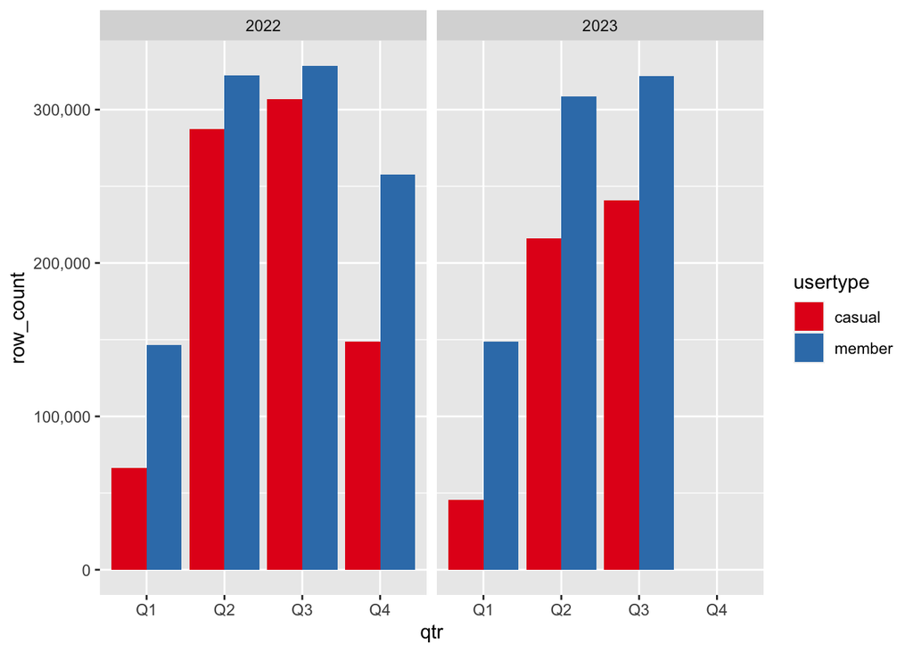

**POINTS TO NOTE**

##### Which user type use bikes more per month?

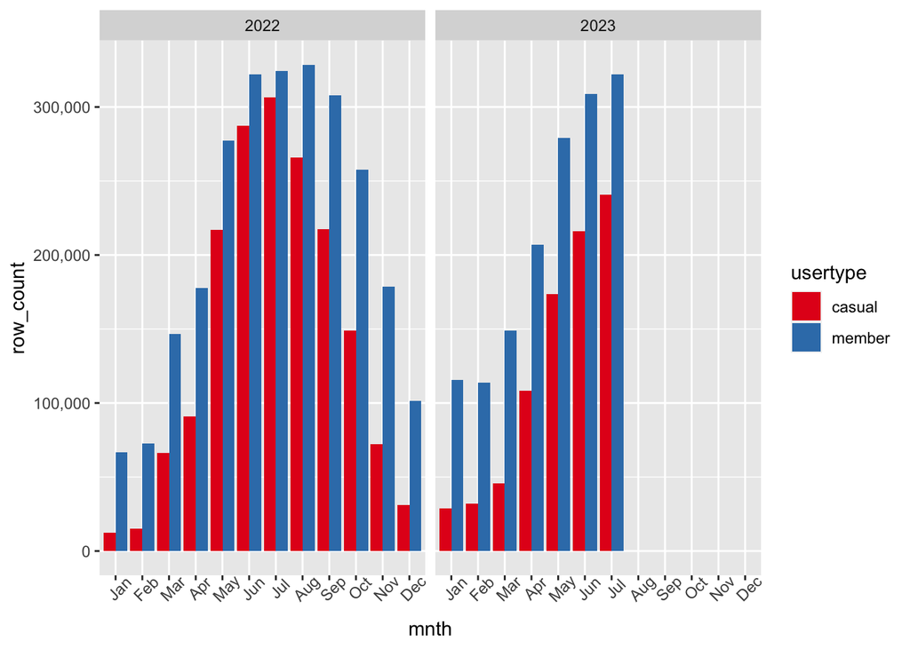

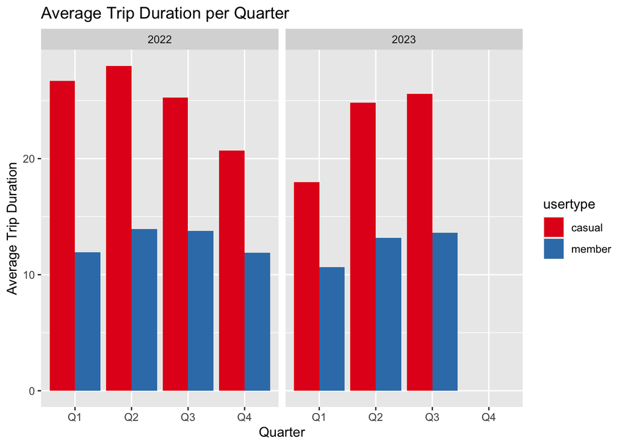

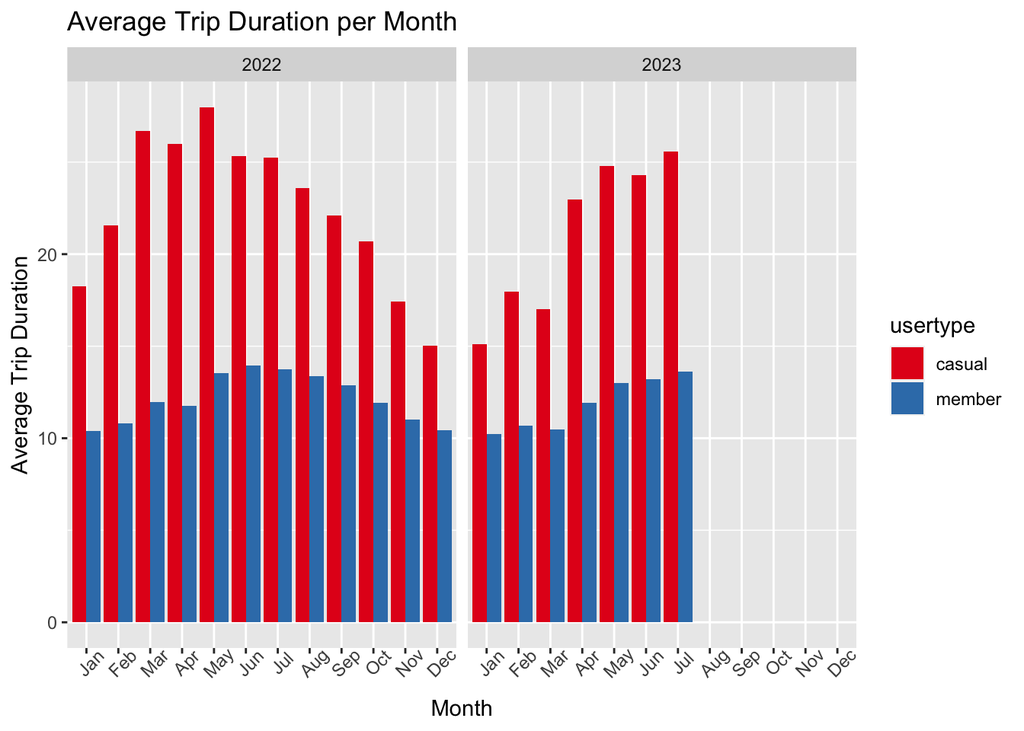

- Top 10 start stations used by casual users.

```
## # A tibble: 10 × 3
##    from_station_name                  row_count percentage
##    <chr>                                  <int>      <dbl>
##  1 Streeter Dr & Grand Ave                78838      1.19
##  2 DuSable Lake Shore Dr & Monroe St      45948      0.693
##  3 Michigan Ave & Oak St                  35540      0.536
##  4 Millennium Park                        34379      0.518
##  5 DuSable Lake Shore Dr & North Blvd     33088      0.499
##  6 Shedd Aquarium                         28243      0.426
##  7 Theater on the Lake                    26126      0.394
##  8 Wells St & Concord Ln                  21046      0.317
##  9 Dusable Harbor                         20962      0.316
## 10 Indiana Ave & Roosevelt Rd             18681      0.282
```

```
## # A tibble: 5 × 3
##   from_station_name            row_count percentage
##   <chr>                            <int>      <dbl>
## 1 Kingsbury St & Kinzie St         36297       0.55
## 2 Clark St & Elm St                32665       0.49
## 3 Clinton St & Washington Blvd     31067       0.47
## 4 Wells St & Concord Ln            29964       0.45
## 5 University Ave & 57th St         27234       0.41
```

- Top 10 end stations used by casual users.

```
## # A tibble: 10 × 4
## # Groups:   usertype [1]
##    usertype to_station_name                    row_count percentage
##    <chr>    <chr>                                  <int>      <dbl>
##  1 casual   Streeter Dr & Grand Ave                84196       1.27
##  2 casual   DuSable Lake Shore Dr & Monroe St      43076       0.65
##  3 casual   DuSable Lake Shore Dr & North Blvd     38302       0.58
##  4 casual   Michigan Ave & Oak St                  38118       0.57
##  5 casual   Millennium Park                        37361       0.56
##  6 casual   Theater on the Lake                    28492       0.43
##  7 casual   Shedd Aquarium                         26052       0.39
##  8 casual   Wells St & Concord Ln                  20573       0.31
##  9 casual   Dusable Harbor                         19960       0.3
## 10 casual   Clark St & Armitage Ave                18962       0.29
```

- Top 10 end stations used by members.

```
## # A tibble: 10 × 4
## # Groups:   usertype [1]
##    usertype to_station_name              row_count percentage
##    <chr>    <chr>                            <int>      <dbl>
##  1 member   Kingsbury St & Kinzie St         36068       0.54
##  2 member   Clark St & Elm St                32810       0.49
##  3 member   Clinton St & Washington Blvd     32539       0.49
##  4 member   Wells St & Concord Ln            31132       0.47
##  5 member   Clinton St & Madison St          28349       0.43
##  6 member   University Ave & 57th St         28223       0.43
##  7 member   Wells St & Elm St                27316       0.41
##  8 member   Loomis St & Lexington St         27015       0.41
##  9 member   Ellis Ave & 60th St              26246       0.4
## 10 member   Broadway & Barry Ave             25545       0.39
```